# Regression Assignment 2

1. Fit a linear model to the data.

```r
data3<- read.table("C:/Users/HP PAVILION/Downloads/STAT6519 assignment 2 datasets/As2Prob3 Data.txt", header = T)
# n2 = number of observations
n2 <- 111
model3 <- lm(data3$Y~data3$X)
summary(model3)
```

```
##
## Call:
## lm(formula = data3$Y ~ data3$X)
##
## Residuals:
##     Min      1Q  Median      3Q     Max
## -6.3535 -1.3154  0.0036  1.2405  4.2469
##
## Coefficients:
##             Estimate Std. Error t value Pr(>|t|)
## (Intercept)  6.86349    0.39863   17.22   <2e-16 ***
## data3$X      0.53327    0.03028   17.61   <2e-16 ***
## ---
## Signif. codes:  0 '***' 0.001 '**' 0.01 '*' 0.05 '.' 0.1 ' ' 1
##
## Residual standard error: 2.118 on 109 degrees of freedom
## Multiple R-squared:   0.74,  Adjusted R-squared:  0.7376
## F-statistic: 310.2 on 1 and 109 DF,  p-value: < 2.2e-16
```

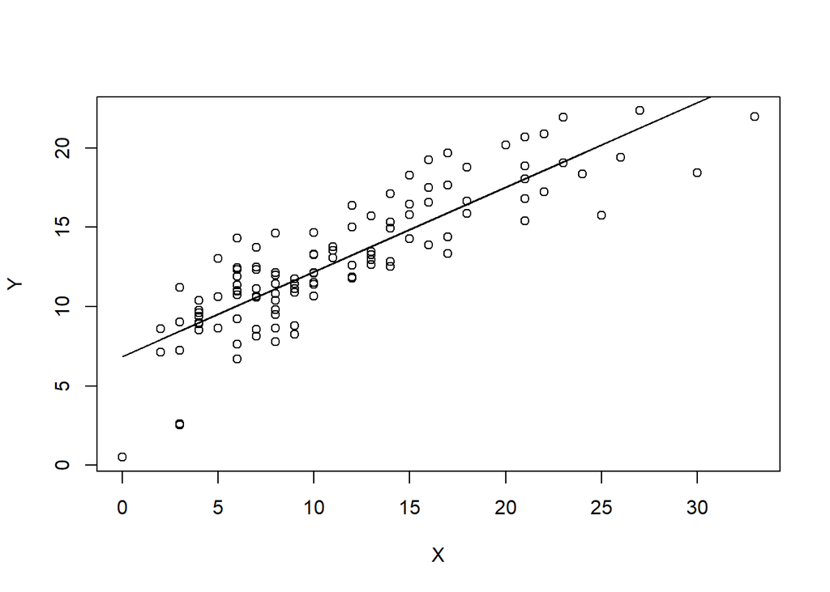

```r
plot(data3$X, data3$Y, ylab = "Y", xlab = "X")
lines(data3$X, fitted(model3))
```

```r
yHat <- 6.86349 + (0.53327 * data3$X)
```

2. Examine the appropriateness of the assumption of linearity. If the assumption of linearity is not valid, apply a suitable transformation to correct the problem.
3. Fit a linear model to the transformed data and perform residual analysis to ex- amine the validity of the model assumptions.

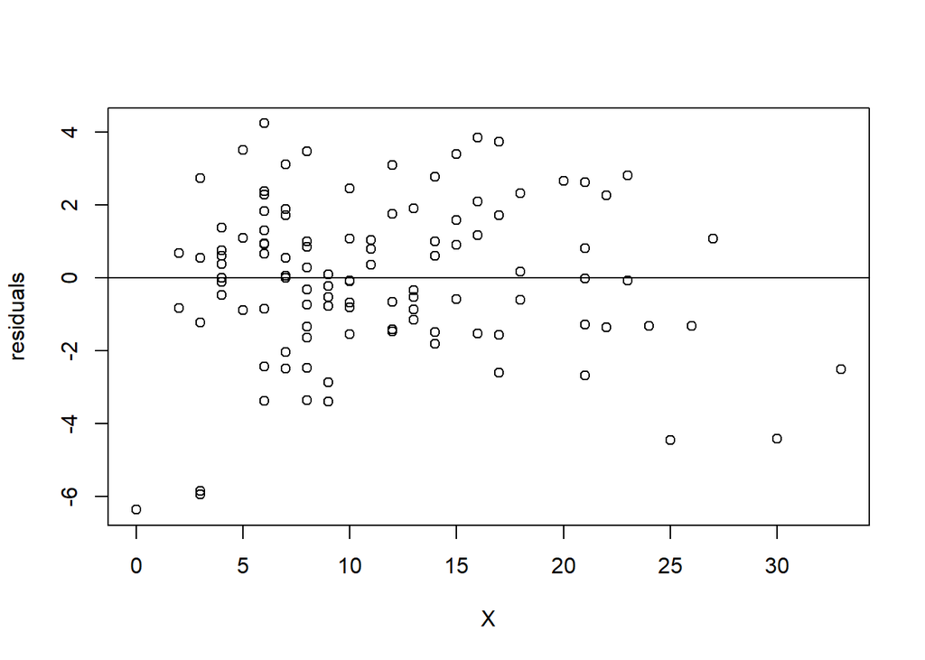

```r
library(MASS)
resi <- resid(model3)
plot(data3$X, resi, xlab = "X", ylab = "residuals", abline(0,0))
```

```r
# square root transformation of the predictor variable

model3_1 <- lm(data3$Y~sqrt(data3$X))
summary(model3_1)
```

```
##
## Call:
## lm(formula = data3$Y ~ sqrt(data3$X))
##
## Residuals:
##     Min      1Q  Median      3Q     Max
## -5.0008 -1.2161  0.0383  1.3367  4.1795
##
## Coefficients:
##               Estimate Std. Error t value Pr(>|t|)
## (Intercept)     1.2547     0.6389   1.964   0.0521 .
## sqrt(data3$X)   3.6235     0.1895  19.124   <2e-16 ***
## ---
## Signif. codes:  0 '***' 0.001 '**' 0.01 '*' 0.05 '.' 0.1 ' ' 1
##
## Residual standard error: 1.99 on 109 degrees of freedom
## Multiple R-squared:  0.7704, Adjusted R-squared:  0.7683
## F-statistic: 365.7 on 1 and 109 DF,  p-value: < 2.2e-16
```

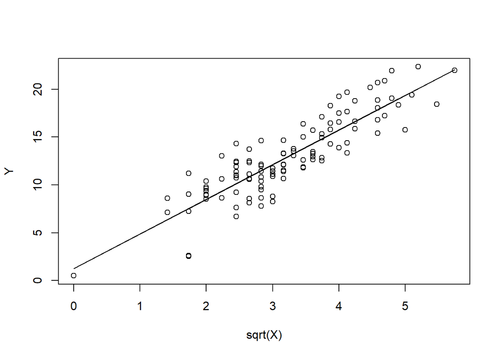

```r
plot(sqrt(data3$X), data3$Y, xlab = "sqrt(X)", ylab = "Y")
lines(sqrt(data3$X), fitted(model3_1))
```

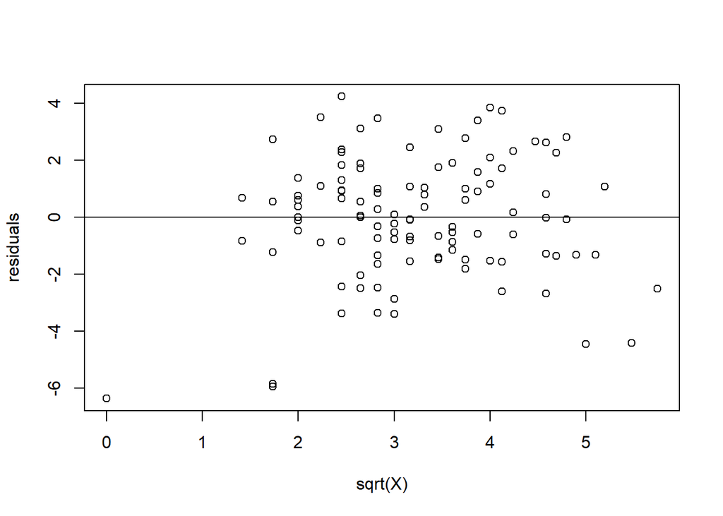

```r
plot(sqrt(data3$X), resi, xlab = "sqrt(X)", ylab = "residuals", abline(0,0))
```

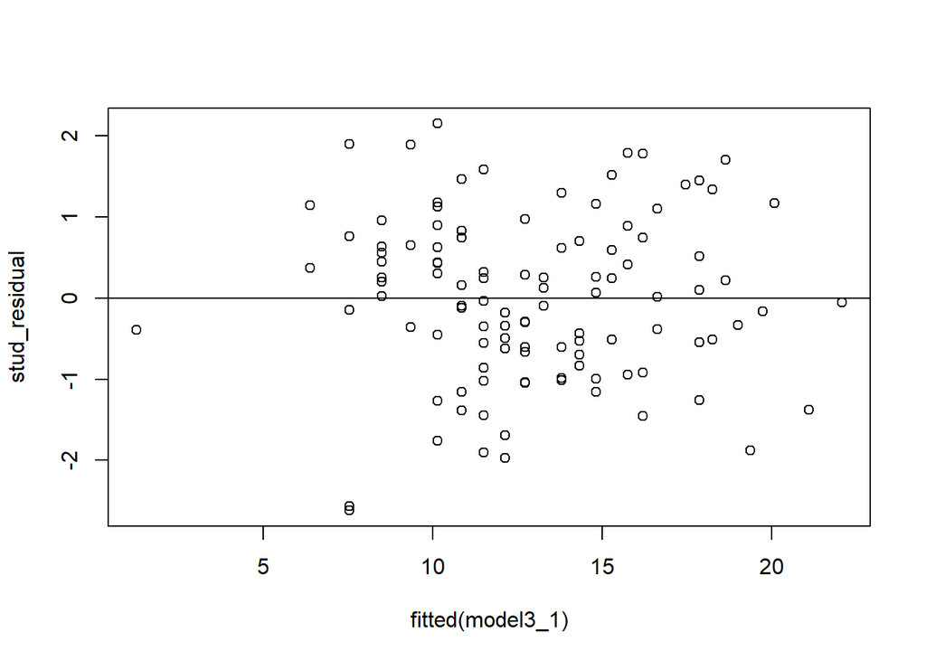

```r
stud_residual <- studres(model3_1)
plot(fitted(model3_1), stud_residual, abline(0,0))
```

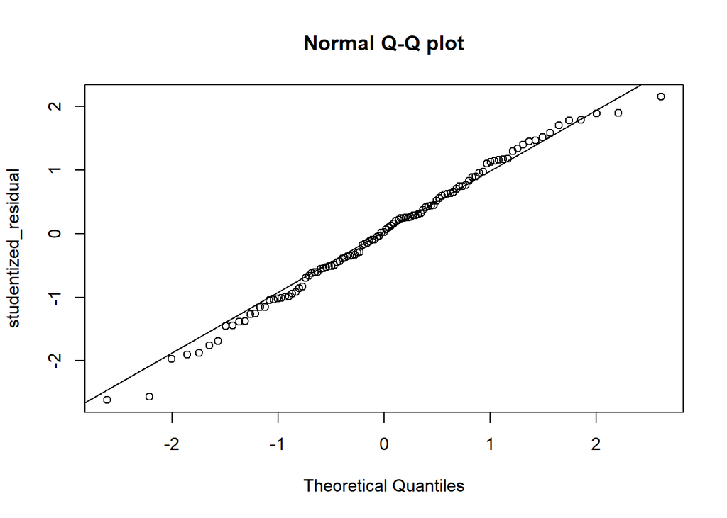

```r
qqnorm(y = studres(model3_1), main = "Normal Q-Q plot", xlab = "Theoretical Quantiles", ylab = "studentized_residual", plot.it = TRUE)
qqline(y= studres(model3_1), distribution = qnorm)
```

After the square root transformation of the predictor axis, the semistudentized residuals fall within a horizontal band centered around the zero line, displaying no systematic pattern of positive and negative values. This shows that the assumption of linearity and constant variance is valid for these data sets.

Also, in the normal Q-Q plot, all the points fall approximately in the line. Then we can say it follows an approximate normal distribution

4. Express the estimated regression function in the original units.

yhat = 1.2547 + (3.6235 * sqrt(X))

QUESTION 4 A chemist studied the concentration of a solution (y) over time (x). Fifteen identical solutions were prepared. The 15 solutions were randomly divided into five sets of three and the five sets were measured, respectively, after 1, 3, 5, 7 and 9 hours. The data is attached.

1. Perform a lack of t test to determine if a linear model is appropriate.

```r
library(tidyverse)
```

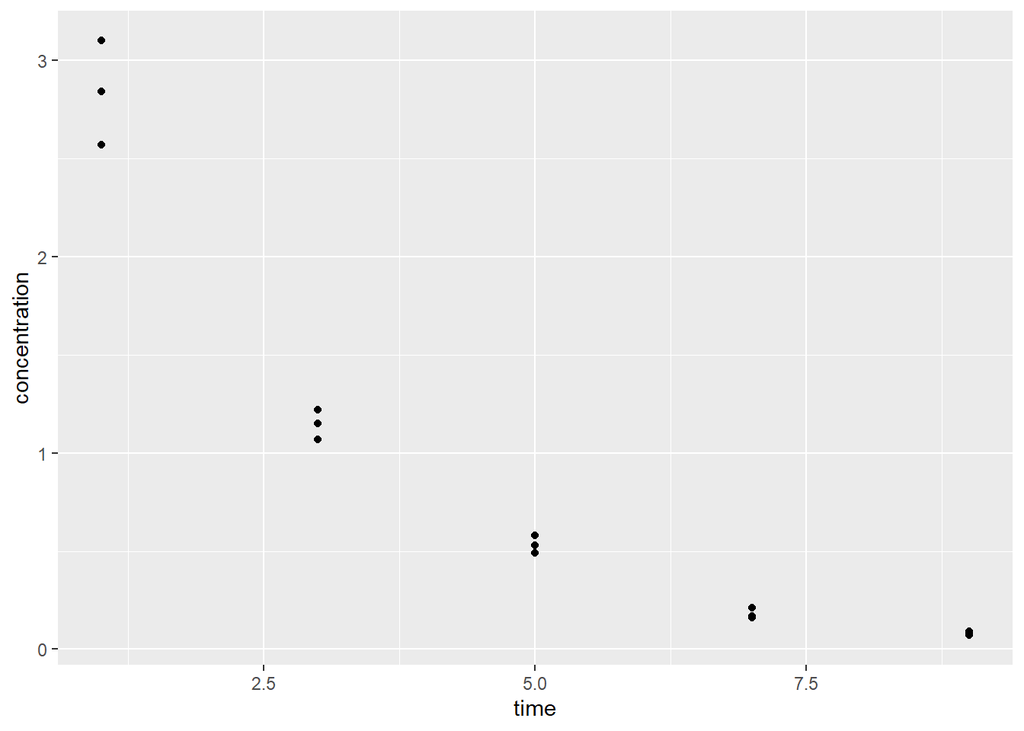

```r
library(MASS)
data4 <- read.table("C:/Users/HP PAVILION/Downloads/STAT6519 assignment 2 datasets/As2Prob4 Data.txt", header = T)
concentration <- data4$Y
time <- data4$X
ggplot(data = data4, mapping = aes(x = time, y = concentration)) + geom_point()
```

```r
 # fitting two regression models to the dataset

full <- lm(concentration ~ poly(time, 2), data = data4)

reduced <- lm(concentration ~ time, data = data4)

#lack of fit test
anova(full, reduced)
```

```
## Analysis of Variance Table
##
## Model 1: concentration ~ poly(time, 2)
## Model 2: concentration ~ time
##   Res.Df     RSS Df Sum of Sq      F    Pr(>F)
## 1     12 0.38888
## 2     13 2.92465 -1   -2.5358 78.248 1.325e-06 ***
## ---
## Signif. codes:  0 '***' 0.001 '**' 0.01 '*' 0.05 '.' 0.1 ' ' 1
```

The F test-statistic turns out to be 78.248 and the corresponding p-value is 1.325e-06. Since the p-value is less than 0.05, we reject the null hypothesis of the test and conclude that the full model offers a statistically better fit than the reduced model.

2. Apply the transformation y* = log10y. Obtain the estimated linear regression function for y* and examine the adequacy of the model.

```r
model4 <- lm(log10(data4$Y)~data4$X)
summary(model4)
```

```
##
## Call:
## lm(formula = log10(data4$Y) ~ data4$X)
##
## Residuals:
##       Min        1Q    Median        3Q       Max
## -0.082958 -0.044421  0.006813  0.033512  0.085550
##
## Coefficients:
##              Estimate Std. Error t value Pr(>|t|)
## (Intercept)  0.654880   0.026181   25.01 2.22e-12 ***
## data4$X     -0.195400   0.004557  -42.88 2.19e-15 ***
## ---
## Signif. codes:  0 '***' 0.001 '**' 0.01 '*' 0.05 '.' 0.1 ' ' 1
##
## Residual standard error: 0.04992 on 13 degrees of freedom
## Multiple R-squared:  0.993,  Adjusted R-squared:  0.9924
## F-statistic:  1838 on 1 and 13 DF,  p-value: 2.188e-15
```

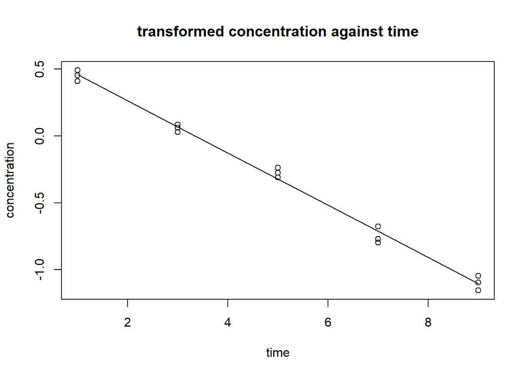

```r
plot(data4$X, log10(data4$Y), xlab = "time", ylab = "concentration", main = "transformed concentration against time")
lines(data4$X, fitted(model4))
```

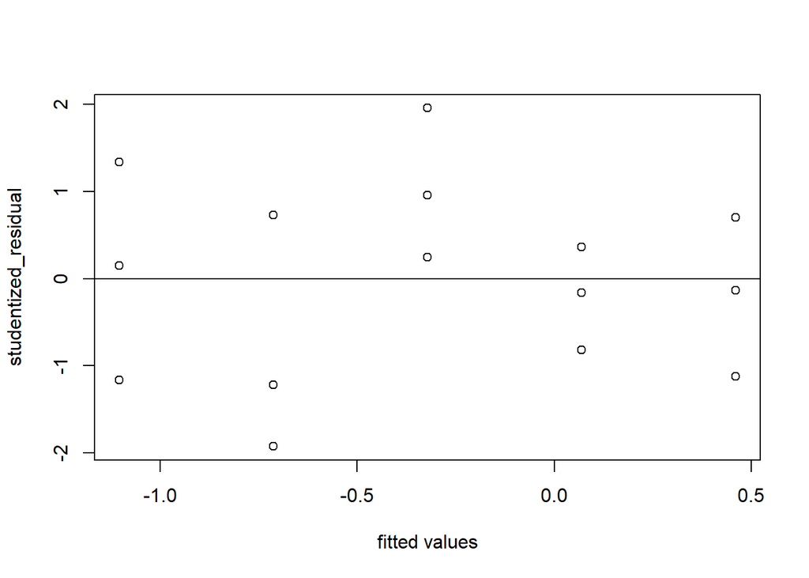

```r
# The estimated regression function is:
# yhat <- 0.654880 - (0.195400 * data4$X)
res <- resid(model4)
studentized_residual <- studres(model4)
plot(fitted(model4), studentized_residual, xlab = "fitted values", ylab = "studentized_residual", abline(0,0))
```